# NHS Borders Incidence Report

In order to create a report in line with the brief, I decided to focus mainly on the dataset containing details of cancer incidences and rates in different health board areas.

Unlike the national data, the regional data isn’t broken down into age group. Instead, we are only given an incidences_all_ages column, along with with is described as a “crude rate”. For a task in this time frame and presentation length, I decided to focus on the incidence numbers and the crude rate, rather than exploring the EASR (European Age Standardized Rate), WASR (World…) and figures related to their respective confidence intervals. For reference, the crude rate is defined as follows:

“The number of cases divided by the population. The crude rate does not attempt to adjust for differences in age and sex structures between different populations (see EASR, WASR etc.).Typically expressed as the number of cases per 100,000 population.”

What we do have is a breakdown of different types of cancer, and a breakdown in terms of the sexes. We should be able to get some insights here with a focus on conclusions linking back to the “planning for provision of cancer treatment services in NHS Borders”.

With this in mind, I wanted to focus on clear differences between NHS Borders figures and overall national figures in order to highlight any major divergences. I decided to replicate three graphs that have been provided for the overall Scottish context. These graphs are contained in the *Cancer Incidence in Scotland (2016)* report, published in 2018:

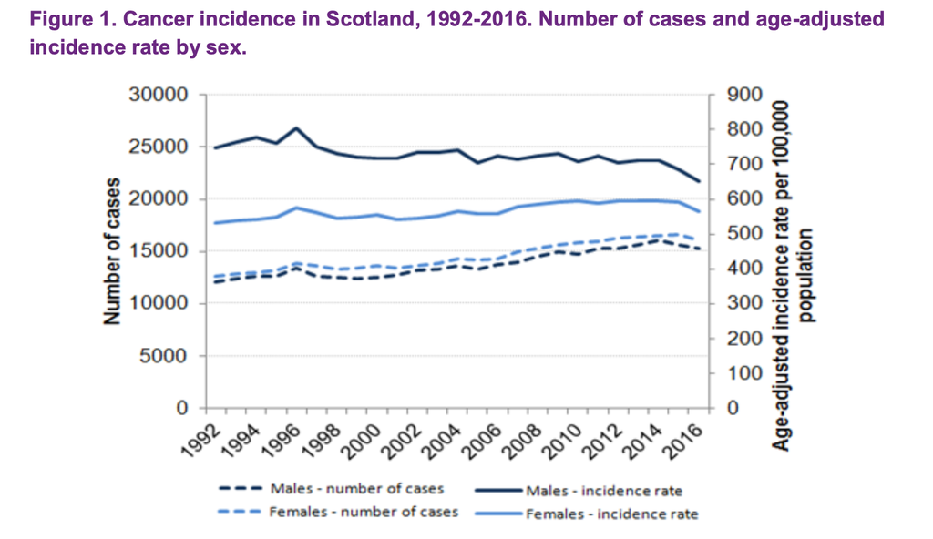

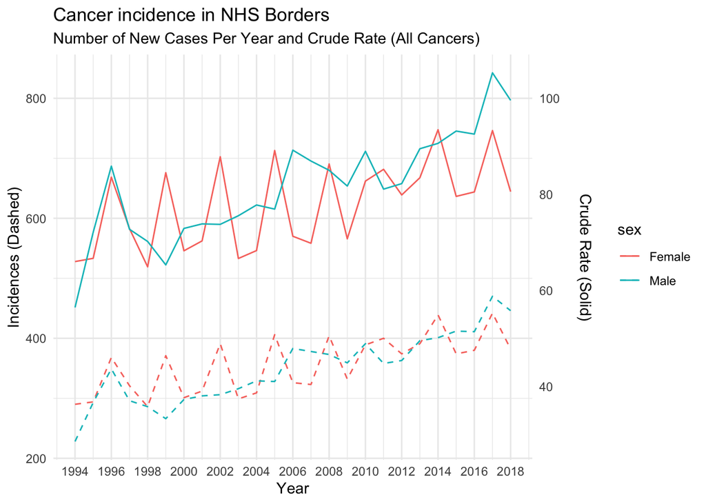

**Another note on fluctuating trends**

As the report states, it may be misleading to focus too much attention on any apparent changes in incidence between 2015 and 2016; it is more informative to examine trends in incidence observed over a number of years. Striking changes from one year to the next may occur in the case of rare cancers, but these are likely to reflect random fluctuation caused by small numbers of cases - in such cases, it is even more important to examine incidence rates for a number of years aggregated together, rather than focusing on a single year of incidence.

**With this in mind, I decided to smooth out the overall rates for cancer incidences and crude rates by Male and Female in NHS Borders:**

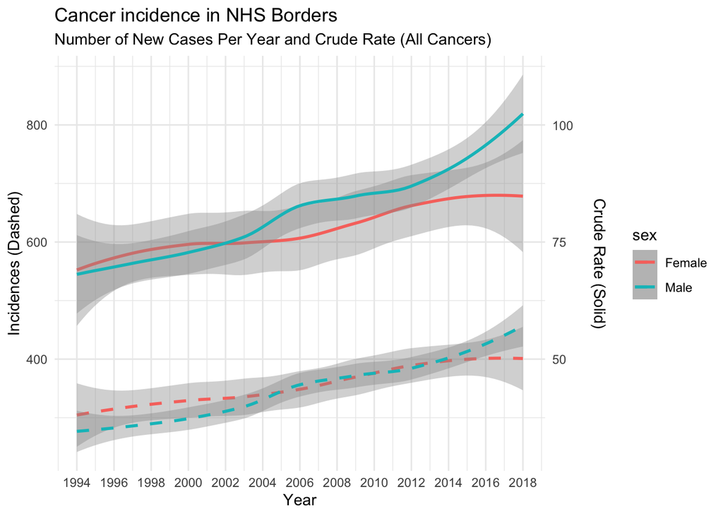

So, taking out the fluctuating trends among Female cancer cases, we see that Male cancer rates appear to have overtaken Female cancer rates, with a gap that looks like it will be maintained in the coming years. This gap is mirrored to an extent in the original All Scotland map above, although in recent years (up to 2016), this gap appeared to be narrowing.

The next figure from the aforementioned annual report addresses the 20 most common types of cancer in Scotland in the year 2016:

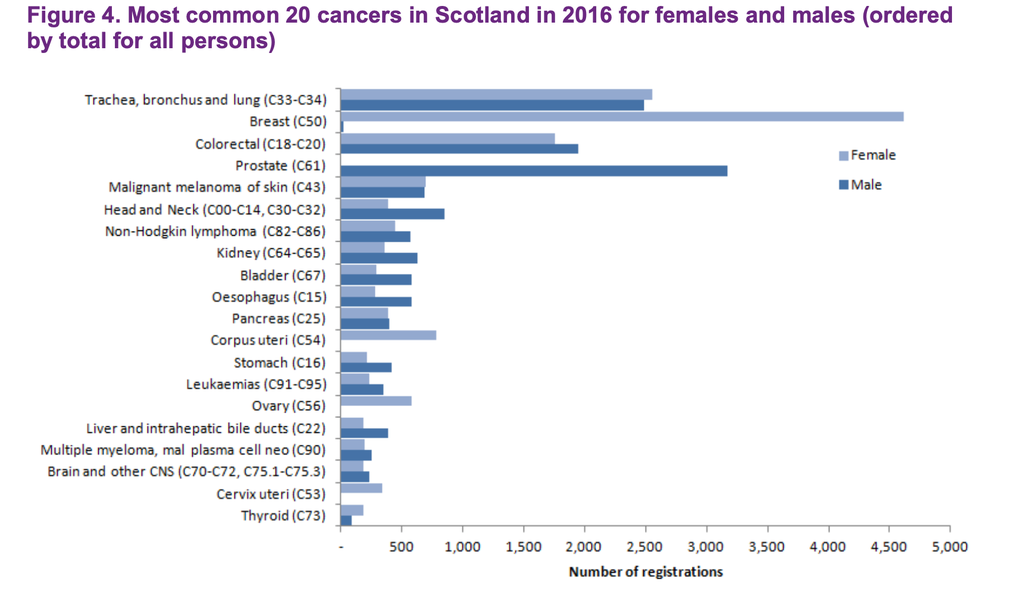

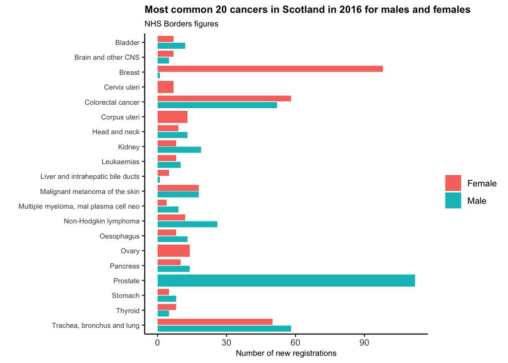

Naturally, the x-axis in this case shows a scale with far smaller measurements than the original plot. However, I think comparing the two visuals is quite useful for immediately assessing the relative prevalence of different types of cancers on a regional and national scale.

The final plot from the original report that I wanted to replicate was a graph that showed the 10 year percentage change in the above cancers between 2006 and 2016:

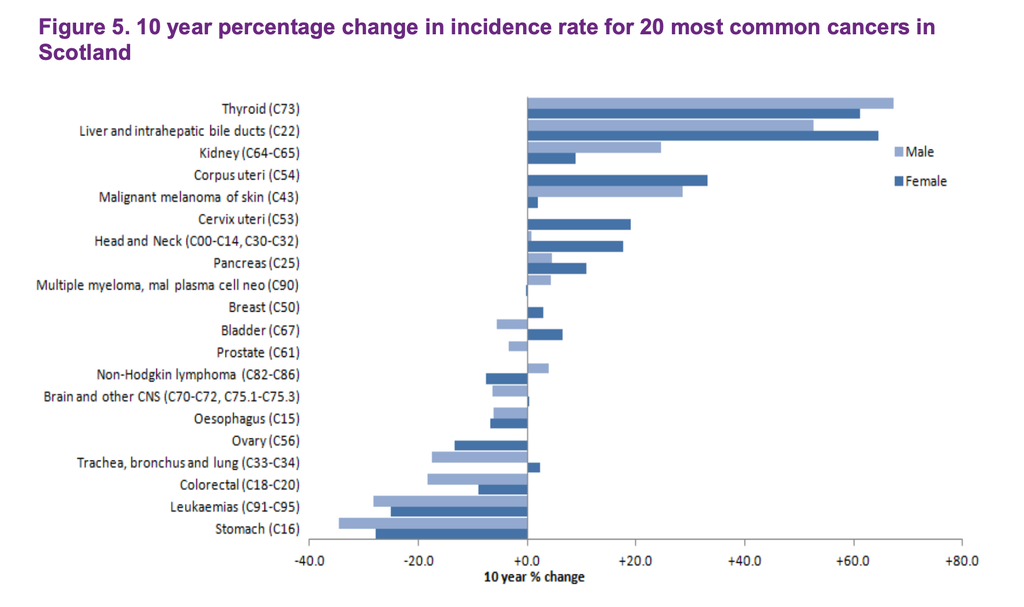

Once again, the aim here was to try to create a replicate plot for NHS Borders that showed some of the comparable changes over the same time frame. In addressing the above graph, I understood that the “10 year % change” referred to was a relative one. However, in trying to replicate a relative percentage change I had a couple of problems. Because of the relatively low numbers of new incidents among certain cancers, the percentage change of rate was throwing up some highly misleading results (anywhere between -150 to 340, not including the one example of infinity). Instead, I decided to go for a graph that although not directly comparable, certainly provides a better insight:

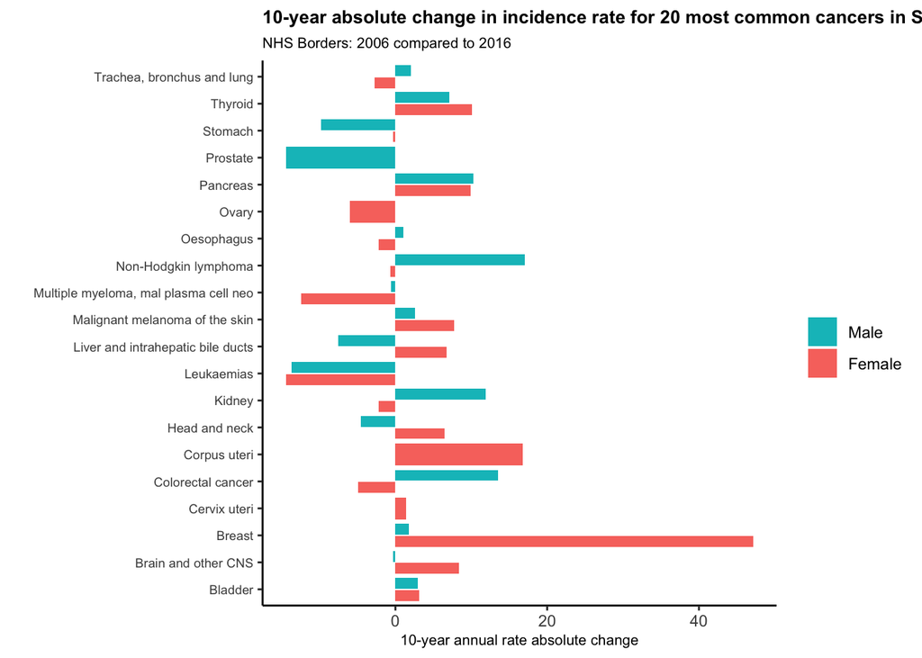